# Tau-U power analysis

Jürgen Wilbert

2022-05-18

# Figure single-case parameters

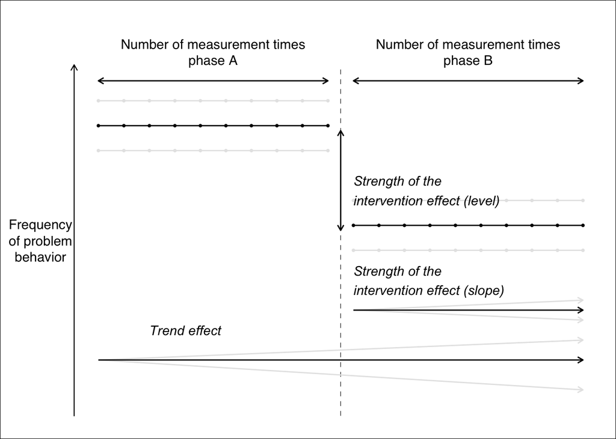

# Example single-cases

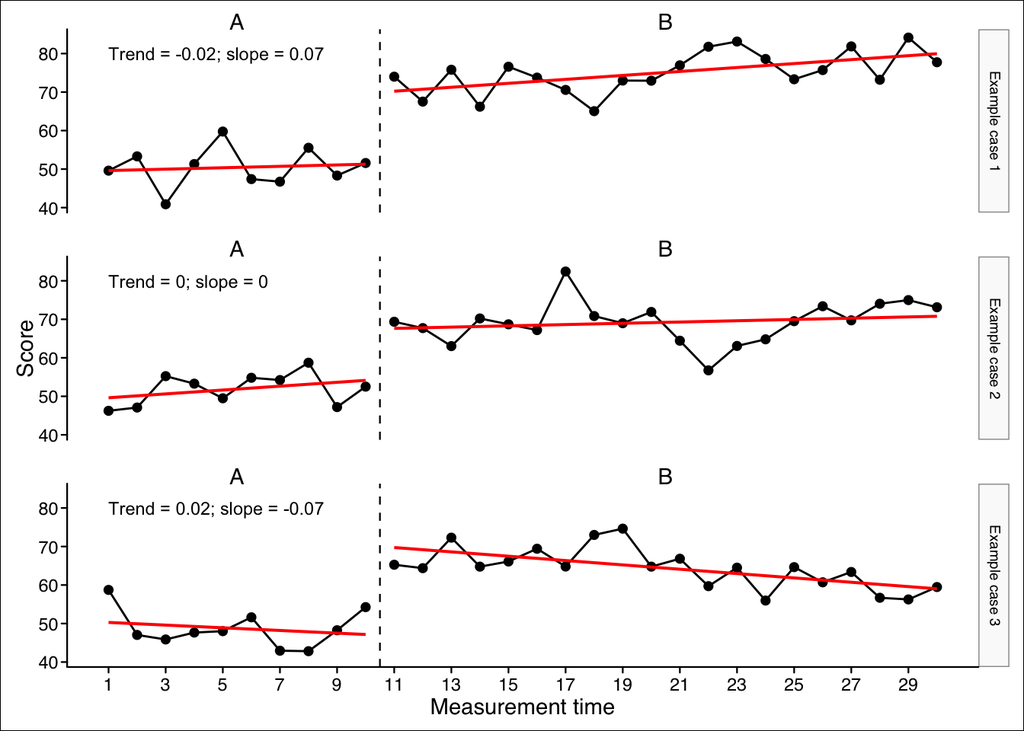

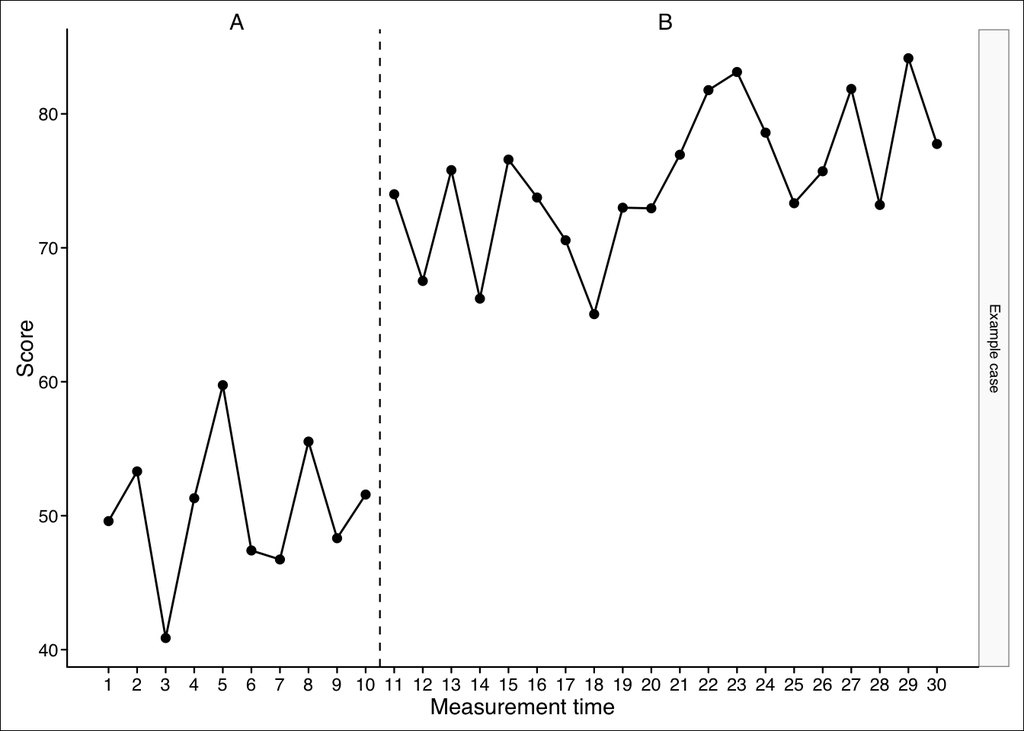

Piecewise-regression model predicting variable ‘values’

| Parameter | B | CI(95%) 2.5% | CI(95%) 97.5% | SE | t | p | Delta R² |
| --- | --- | --- | --- | --- | --- | --- | --- |
| Intercept | 49.43 | 42.98 | 55.89 | 3.29 | 15.01 | <.001 |  |
| Trend mt | 0.18 | -0.86 | 1.22 | 0.53 | 0.34 | .73 | .00 |
| Level phase B | 18.45 | 11.37 | 25.53 | 3.61 | 5.11 | <.001 | .13 |
| Slope phase B | 0.33 | -0.77 | 1.43 | 0.56 | 0.59 | .56 | .00 |

Note:  
F(3, 26) = 60.65; p <.001; R² = 0.875; Adjusted R² = 0.861

Piecewise-regression model predicting variable ‘values’

| Parameter | B | CI(95%) 2.5% | CI(95%) 97.5% | SE | t | p | Delta R² |
| --- | --- | --- | --- | --- | --- | --- | --- |
| Intercept | 49.12 | 42.31 | 55.93 | 3.48 | 14.13 | <.001 |  |
| Trend mt | 0.50 | -0.60 | 1.60 | 0.56 | 0.90 | .37 | .01 |
| Level phase B | 13.33 | 5.86 | 20.80 | 3.81 | 3.50 | <.01 | .12 |
| Slope phase B | -0.34 | -1.50 | 0.83 | 0.59 | -0.57 | .57 | .00 |

Note:  
F(3, 26) = 26.28; p <.001; R² = 0.752; Adjusted R² = 0.723

Piecewise-regression model predicting variable ‘values’

| Parameter | B | CI(95%) 2.5% | CI(95%) 97.5% | SE | t | p | Delta R² |
| --- | --- | --- | --- | --- | --- | --- | --- |
| Intercept | 50.63 | 44.57 | 56.70 | 3.09 | 16.36 | <.001 |  |
| Trend mt | -0.35 | -1.33 | 0.63 | 0.50 | -0.70 | .49 | .0 |
| Level phase B | 23.15 | 16.50 | 29.80 | 3.39 | 6.82 | <.001 | .4 |
| Slope phase B | -0.22 | -1.25 | 0.82 | 0.53 | -0.41 | .68 | .0 |

Note:  
F(3, 26) = 30.16; p <.001; R² = 0.777; Adjusted R² = 0.751

# Length of A and B phase

## Percentage significant

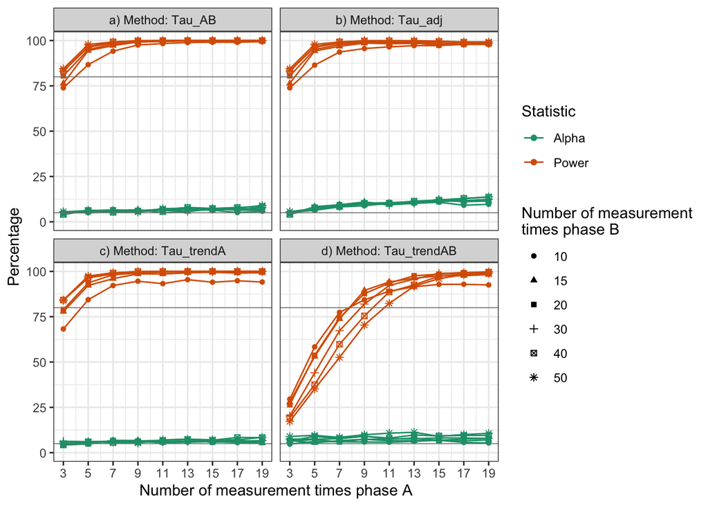

| A | B | Power Tau<sub>AB</sub> | Power Tau<sub>trendA</sub> | Power Tau<sub>trendA+B</sub> | Power Tau<sub>adj</sub> | Alpha error Tau<sub>AB</sub> | Alpha error Tau<sub>trendA</sub> | Alpha error Tau<sub>trendA+B</sub> | Alpha error Tau<sub>adj</sub> | Correct Tau<sub>AB</sub> | Correct Tau<sub>trendA</sub> | Correct Tau<sub>trendA+B</sub> | Correct Tau<sub>adj</sub> |
| --- | --- | --- | --- | --- | --- | --- | --- | --- | --- | --- | --- | --- | --- |
| 3 | 10 | 74 | 68 | 30 | 74 | 5 | 4 | 5 | 5 | 84 | 82 | 62 | 84 |
| 3 | 15 | 76 | 78 | 28 | 76 | 4 | 5 | 7 | 4 | 86 | 86 | 61 | 86 |
| 3 | 20 | 81 | 79 | 26 | 81 | 5 | 4 | 6 | 5 | 88 | 87 | 60 | 88 |
| 3 | 30 | 83 | 84 | 20 | 83 | 5 | 6 | 8 | 5 | 89 | 89 | 56 | 89 |
| 3 | 40 | 83 | 84 | 19 | 83 | 4 | 4 | 7 | 4 | 90 | 90 | 56 | 90 |
| 3 | 50 | 84 | 84 | 17 | 84 | 6 | 5 | 9 | 6 | 89 | 89 | 54 | 89 |
| 5 | 10 | 87 | 84 | 58 | 86 | 5 | 6 | 6 | 6 | 91 | 89 | 76 | 90 |
| 5 | 15 | 94 | 92 | 53 | 94 | 6 | 5 | 5 | 8 | 94 | 94 | 74 | 93 |
| 5 | 20 | 95 | 94 | 54 | 95 | 6 | 5 | 7 | 7 | 95 | 94 | 73 | 94 |
| 5 | 30 | 96 | 96 | 44 | 96 | 6 | 6 | 7 | 7 | 95 | 95 | 68 | 94 |
| 5 | 40 | 97 | 97 | 38 | 97 | 6 | 6 | 9 | 8 | 95 | 95 | 64 | 94 |
| 5 | 50 | 98 | 97 | 35 | 98 | 6 | 6 | 10 | 7 | 96 | 96 | 63 | 95 |
| 7 | 10 | 94 | 92 | 77 | 94 | 6 | 6 | 6 | 8 | 94 | 93 | 86 | 93 |
| 7 | 15 | 97 | 96 | 74 | 97 | 6 | 7 | 7 | 9 | 95 | 95 | 84 | 94 |
| 7 | 20 | 98 | 98 | 74 | 98 | 7 | 7 | 6 | 10 | 96 | 96 | 84 | 94 |
| 7 | 30 | 99 | 99 | 67 | 99 | 6 | 6 | 8 | 9 | 96 | 96 | 80 | 95 |
| 7 | 40 | 99 | 99 | 60 | 99 | 5 | 6 | 8 | 8 | 97 | 97 | 76 | 95 |
| 7 | 50 | 99 | 99 | 53 | 99 | 6 | 6 | 8 | 8 | 97 | 97 | 72 | 95 |
| 9 | 10 | 98 | 95 | 84 | 96 | 6 | 6 | 6 | 9 | 96 | 94 | 89 | 93 |
| 9 | 15 | 99 | 99 | 90 | 99 | 7 | 7 | 7 | 11 | 96 | 96 | 91 | 94 |
| 9 | 20 | 100 | 99 | 88 | 99 | 6 | 6 | 7 | 10 | 97 | 96 | 90 | 94 |
| 9 | 30 | 100 | 100 | 82 | 99 | 6 | 6 | 9 | 11 | 97 | 97 | 86 | 94 |
| 9 | 40 | 100 | 100 | 75 | 100 | 6 | 6 | 9 | 10 | 97 | 97 | 83 | 95 |
| 9 | 50 | 100 | 100 | 70 | 100 | 5 | 5 | 10 | 10 | 97 | 97 | 80 | 95 |
| 11 | 10 | 98 | 93 | 89 | 96 | 6 | 5 | 6 | 10 | 96 | 94 | 92 | 93 |
| 11 | 15 | 99 | 99 | 94 | 98 | 5 | 6 | 7 | 9 | 97 | 96 | 94 | 94 |
| 11 | 20 | 100 | 100 | 94 | 99 | 7 | 7 | 7 | 11 | 96 | 96 | 93 | 94 |
| 11 | 30 | 100 | 100 | 92 | 100 | 6 | 6 | 8 | 9 | 97 | 97 | 92 | 95 |
| 11 | 40 | 100 | 100 | 89 | 100 | 7 | 7 | 8 | 10 | 97 | 97 | 90 | 95 |
| 11 | 50 | 100 | 100 | 82 | 100 | 7 | 7 | 11 | 10 | 96 | 96 | 86 | 95 |
| 13 | 10 | 99 | 95 | 92 | 97 | 7 | 6 | 6 | 10 | 96 | 95 | 93 | 94 |
| 13 | 15 | 100 | 99 | 96 | 98 | 6 | 6 | 7 | 10 | 97 | 96 | 95 | 94 |
| 13 | 20 | 100 | 100 | 98 | 99 | 7 | 7 | 8 | 11 | 96 | 96 | 95 | 94 |
| 13 | 30 | 100 | 100 | 96 | 99 | 6 | 6 | 8 | 10 | 97 | 97 | 94 | 94 |
| 13 | 40 | 100 | 100 | 93 | 100 | 8 | 7 | 10 | 11 | 96 | 96 | 91 | 94 |
| 13 | 50 | 100 | 100 | 92 | 100 | 8 | 7 | 11 | 11 | 96 | 96 | 90 | 94 |
| 15 | 10 | 99 | 94 | 93 | 97 | 6 | 6 | 7 | 11 | 96 | 94 | 93 | 93 |
| 15 | 15 | 100 | 100 | 98 | 98 | 7 | 6 | 7 | 12 | 96 | 97 | 95 | 93 |
| 15 | 20 | 100 | 100 | 98 | 97 | 7 | 6 | 7 | 11 | 97 | 97 | 96 | 93 |
| 15 | 30 | 100 | 100 | 99 | 99 | 7 | 7 | 8 | 12 | 97 | 97 | 95 | 93 |
| 15 | 40 | 100 | 100 | 97 | 100 | 7 | 7 | 9 | 12 | 96 | 97 | 94 | 94 |
| 15 | 50 | 100 | 100 | 96 | 100 | 7 | 7 | 9 | 12 | 96 | 96 | 93 | 94 |
| 17 | 10 | 99 | 95 | 93 | 98 | 5 | 6 | 6 | 9 | 97 | 95 | 94 | 94 |
| 17 | 15 | 100 | 99 | 98 | 98 | 6 | 6 | 6 | 11 | 97 | 96 | 96 | 94 |
| 17 | 20 | 100 | 100 | 99 | 98 | 7 | 7 | 8 | 12 | 96 | 97 | 96 | 93 |
| 17 | 30 | 100 | 100 | 99 | 98 | 7 | 6 | 8 | 12 | 97 | 97 | 96 | 93 |
| 17 | 40 | 100 | 100 | 99 | 99 | 8 | 8 | 10 | 13 | 96 | 96 | 95 | 93 |
| 17 | 50 | 100 | 100 | 98 | 99 | 8 | 7 | 10 | 13 | 96 | 96 | 94 | 93 |
| 19 | 10 | 99 | 94 | 93 | 98 | 6 | 6 | 5 | 10 | 97 | 94 | 94 | 94 |
| 19 | 15 | 100 | 99 | 98 | 98 | 6 | 5 | 7 | 11 | 97 | 97 | 96 | 93 |
| 19 | 20 | 100 | 100 | 99 | 98 | 7 | 6 | 8 | 11 | 97 | 97 | 96 | 93 |
| 19 | 30 | 100 | 100 | 100 | 98 | 8 | 7 | 8 | 12 | 96 | 97 | 96 | 93 |
| 19 | 40 | 100 | 100 | 100 | 99 | 8 | 8 | 10 | 14 | 96 | 96 | 95 | 93 |
| 19 | 50 | 100 | 100 | 99 | 99 | 9 | 8 | 11 | 14 | 96 | 96 | 94 | 93 |

| A | B | Power Tau<sub>AB</sub> | Power Tau<sub>trendA</sub> | Power Tau<sub>trendA+B</sub> | Power Tau<sub>adj</sub> | Alpha error Tau<sub>AB</sub> | Alpha error Tau<sub>trendA</sub> | Alpha error Tau<sub>trendA+B</sub> | Alpha error Tau<sub>adj</sub> | Correct Tau<sub>AB</sub> | Correct Tau<sub>trendA</sub> | Correct Tau<sub>trendA+B</sub> | Correct Tau<sub>adj</sub> |
| --- | --- | --- | --- | --- | --- | --- | --- | --- | --- | --- | --- | --- | --- |
| 3 | 10 | 73.90 | -6 | -44 | 0 | 5.20 | -1 | 0 | 0 | 84.350 | -2 | -22 | 0 |
| 3 | 15 | 76.35 | 2 | -48 | 0 | 4.10 | 1 | 2 | 0 | 86.125 | 0 | -26 | 0 |
| 3 | 20 | 80.55 | -2 | -54 | 0 | 4.85 | -1 | 1 | 0 | 87.850 | -1 | -28 | 0 |
| 3 | 30 | 83.15 | 1 | -63 | 0 | 5.40 | 1 | 2 | 0 | 88.875 | 0 | -32 | 0 |
| 3 | 40 | 83.35 | 1 | -64 | 0 | 4.00 | 0 | 3 | 0 | 89.675 | 0 | -33 | 0 |
| 3 | 50 | 84.45 | 0 | -67 | 0 | 5.60 | 0 | 3 | 0 | 89.425 | 0 | -35 | 0 |
| 5 | 10 | 86.70 | -2 | -28 | 0 | 5.00 | 1 | 1 | 1 | 90.850 | -2 | -15 | -1 |
| 5 | 15 | 94.45 | -2 | -41 | 0 | 6.35 | -1 | -1 | 2 | 94.050 | 0 | -20 | -1 |
| 5 | 20 | 95.00 | -1 | -41 | 0 | 5.90 | -1 | 1 | 2 | 94.550 | 0 | -21 | -1 |
| 5 | 30 | 96.30 | 0 | -52 | 0 | 6.25 | 0 | 1 | 1 | 95.025 | 0 | -27 | -1 |
| 5 | 40 | 96.65 | 0 | -59 | 0 | 6.30 | 0 | 3 | 2 | 95.175 | 0 | -31 | -1 |
| 5 | 50 | 97.85 | 0 | -63 | 0 | 5.90 | 0 | 4 | 1 | 95.975 | 0 | -33 | -1 |
| 7 | 10 | 94.15 | -2 | -17 | 0 | 5.60 | 1 | 0 | 3 | 94.275 | -1 | -9 | -2 |
| 7 | 15 | 97.20 | -1 | -23 | 0 | 6.25 | 0 | 0 | 3 | 95.475 | -1 | -12 | -2 |
| 7 | 20 | 98.15 | 0 | -24 | 0 | 6.65 | 0 | -1 | 3 | 95.750 | 0 | -12 | -2 |
| 7 | 30 | 98.80 | 0 | -31 | 0 | 6.00 | 0 | 2 | 3 | 96.400 | 0 | -17 | -1 |
| 7 | 40 | 99.25 | 0 | -39 | 0 | 5.20 | 0 | 3 | 3 | 97.025 | 0 | -21 | -2 |
| 7 | 50 | 99.20 | 0 | -47 | 0 | 6.15 | 0 | 2 | 2 | 96.525 | 0 | -24 | -1 |
| 9 | 10 | 97.55 | -3 | -13 | -2 | 5.50 | 1 | 0 | 3 | 96.025 | -2 | -7 | -3 |
| 9 | 15 | 99.20 | -1 | -10 | -1 | 6.65 | 0 | 1 | 4 | 96.275 | 0 | -5 | -2 |
| 9 | 20 | 99.50 | 0 | -12 | -1 | 6.00 | 0 | 1 | 4 | 96.750 | 0 | -7 | -2 |
| 9 | 30 | 99.80 | 0 | -18 | 0 | 6.35 | 0 | 3 | 4 | 96.725 | 0 | -10 | -2 |
| 9 | 40 | 99.85 | 0 | -24 | 0 | 6.00 | 0 | 3 | 4 | 96.925 | 0 | -14 | -2 |
| 9 | 50 | 99.95 | 0 | -30 | 0 | 5.40 | 0 | 4 | 4 | 97.275 | 0 | -17 | -2 |
| 11 | 10 | 98.35 | -5 | -9 | -2 | 6.50 | -1 | -1 | 4 | 95.925 | -2 | -4 | -3 |
| 11 | 15 | 99.45 | -1 | -5 | -1 | 5.00 | 1 | 2 | 4 | 97.225 | -1 | -3 | -3 |
| 11 | 20 | 99.90 | 0 | -6 | -1 | 7.05 | 0 | 0 | 4 | 96.425 | 0 | -3 | -2 |
| 11 | 30 | 99.90 | 0 | -8 | 0 | 6.35 | 0 | 1 | 3 | 96.775 | 0 | -4 | -2 |
| 11 | 40 | 100.00 | 0 | -11 | 0 | 6.75 | 0 | 1 | 3 | 96.625 | 0 | -6 | -2 |
| 11 | 50 | 100.00 | 0 | -18 | 0 | 7.25 | 0 | 4 | 3 | 96.375 | 0 | -11 | -2 |
| 13 | 10 | 98.90 | -3 | -7 | -2 | 6.85 | -1 | -1 | 3 | 96.025 | -1 | -3 | -2 |
| 13 | 15 | 99.75 | -1 | -4 | -1 | 5.65 | 1 | 1 | 5 | 97.050 | -1 | -2 | -3 |
| 13 | 20 | 99.90 | 0 | -2 | -1 | 7.10 | 0 | 1 | 4 | 96.400 | 0 | -2 | -3 |
| 13 | 30 | 99.90 | 0 | -4 | -1 | 5.80 | 0 | 2 | 4 | 97.050 | 0 | -3 | -3 |
| 13 | 40 | 100.00 | 0 | -7 | 0 | 7.95 | -1 | 2 | 3 | 96.025 | 0 | -5 | -2 |
| 13 | 50 | 100.00 | 0 | -8 | 0 | 7.50 | 0 | 4 | 3 | 96.250 | 0 | -6 | -2 |
| 15 | 10 | 99.10 | -5 | -6 | -2 | 6.45 | 0 | 0 | 4 | 96.325 | -2 | -3 | -3 |
| 15 | 15 | 99.95 | 0 | -2 | -2 | 7.30 | -1 | 0 | 4 | 96.325 | 0 | -1 | -3 |
| 15 | 20 | 99.90 | 0 | -1 | -3 | 6.75 | -1 | 0 | 4 | 96.575 | 0 | -1 | -3 |
| 15 | 30 | 99.95 | 0 | -1 | -1 | 6.90 | 0 | 1 | 5 | 96.525 | 0 | -1 | -3 |
| 15 | 40 | 100.00 | 0 | -3 | 0 | 7.35 | 0 | 2 | 5 | 96.325 | 0 | -2 | -3 |
| 15 | 50 | 100.00 | 0 | -4 | 0 | 7.35 | 0 | 2 | 5 | 96.325 | 0 | -3 | -2 |
| 17 | 10 | 99.05 | -4 | -6 | -1 | 5.10 | 0 | 1 | 4 | 96.975 | -2 | -3 | -3 |
| 17 | 15 | 99.80 | -1 | -2 | -2 | 6.40 | 0 | 0 | 5 | 96.700 | 0 | -1 | -3 |
| 17 | 20 | 99.95 | 0 | -1 | -2 | 7.30 | -1 | 0 | 5 | 96.325 | 0 | 0 | -3 |
| 17 | 30 | 100.00 | 0 | -1 | -2 | 6.65 | 0 | 1 | 5 | 96.675 | 0 | -1 | -3 |
| 17 | 40 | 100.00 | 0 | -1 | -1 | 7.90 | 0 | 2 | 5 | 96.050 | 0 | -1 | -3 |
| 17 | 50 | 100.00 | 0 | -2 | -1 | 7.55 | -1 | 2 | 5 | 96.225 | 0 | -2 | -3 |
| 19 | 10 | 99.40 | -5 | -7 | -2 | 5.85 | 0 | -1 | 4 | 96.775 | -2 | -3 | -3 |
| 19 | 15 | 99.85 | -1 | -2 | -2 | 6.50 | -1 | 1 | 5 | 96.675 | 0 | -1 | -3 |
| 19 | 20 | 100.00 | 0 | -1 | -2 | 6.80 | -1 | 1 | 4 | 96.600 | 0 | -1 | -3 |
| 19 | 30 | 100.00 | 0 | 0 | -2 | 7.90 | -1 | 0 | 4 | 96.050 | 1 | 0 | -3 |
| 19 | 40 | 100.00 | 0 | 0 | -1 | 8.45 | 0 | 1 | 5 | 95.775 | 0 | -1 | -3 |
| 19 | 50 | 100.00 | 0 | -1 | -1 | 9.00 | -1 | 2 | 5 | 95.500 | 0 | -1 | -3 |

## Mean Tau

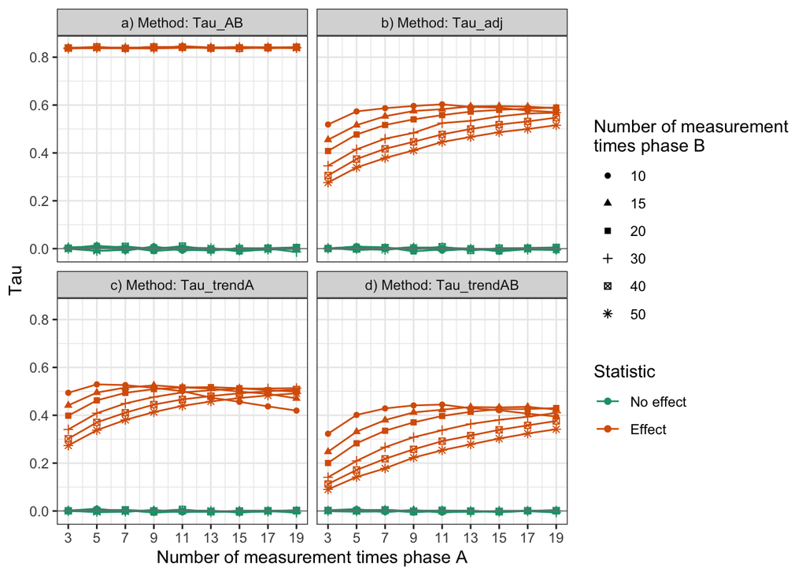

| A | B | Effect Tau<sub>AB</sub> | Effect Tau<sub>trendA</sub> | Effect Tau<sub>trendA+B</sub> | Effect Tau<sub>adj</sub> | No effect Tau<sub>AB</sub> | No effect Tau<sub>trendA</sub> | No effect Tau<sub>trendA+B</sub> | No effect Tau<sub>adj</sub> |
| --- | --- | --- | --- | --- | --- | --- | --- | --- | --- |
| 3 | 10 | 0.84 | 0.49 | 0.32 | 0.52 | 0.00 | 0.00 | 0.00 | 0.00 |
| 3 | 15 | 0.84 | 0.44 | 0.25 | 0.45 | 0.01 | 0.00 | 0.00 | 0.00 |
| 3 | 20 | 0.84 | 0.40 | 0.20 | 0.41 | 0.00 | 0.00 | 0.00 | 0.00 |
| 3 | 30 | 0.84 | 0.34 | 0.14 | 0.35 | 0.01 | 0.00 | 0.00 | 0.00 |
| 3 | 40 | 0.84 | 0.30 | 0.11 | 0.31 | 0.00 | 0.00 | 0.00 | 0.00 |
| 3 | 50 | 0.84 | 0.27 | 0.09 | 0.28 | 0.00 | 0.00 | 0.00 | 0.00 |
| 5 | 10 | 0.84 | 0.53 | 0.40 | 0.57 | 0.01 | 0.01 | 0.01 | 0.01 |
| 5 | 15 | 0.84 | 0.49 | 0.33 | 0.52 | -0.01 | -0.01 | 0.00 | -0.01 |
| 5 | 20 | 0.84 | 0.46 | 0.28 | 0.48 | 0.01 | 0.01 | 0.00 | 0.01 |
| 5 | 30 | 0.84 | 0.41 | 0.21 | 0.41 | 0.01 | 0.00 | 0.00 | 0.00 |
| 5 | 40 | 0.84 | 0.37 | 0.17 | 0.37 | 0.00 | 0.00 | 0.00 | 0.00 |
| 5 | 50 | 0.84 | 0.34 | 0.14 | 0.34 | -0.01 | 0.00 | 0.00 | 0.00 |
| 7 | 10 | 0.84 | 0.53 | 0.43 | 0.59 | -0.01 | 0.00 | -0.01 | 0.00 |
| 7 | 15 | 0.84 | 0.52 | 0.38 | 0.55 | 0.00 | 0.00 | 0.00 | 0.00 |
| 7 | 20 | 0.84 | 0.49 | 0.34 | 0.52 | 0.01 | 0.00 | 0.00 | 0.01 |
| 7 | 30 | 0.84 | 0.45 | 0.27 | 0.46 | 0.00 | 0.00 | 0.01 | 0.00 |
| 7 | 40 | 0.84 | 0.41 | 0.22 | 0.42 | 0.01 | 0.00 | 0.00 | 0.00 |
| 7 | 50 | 0.84 | 0.38 | 0.18 | 0.38 | -0.01 | 0.00 | 0.00 | -0.01 |
| 9 | 10 | 0.84 | 0.51 | 0.44 | 0.60 | 0.01 | 0.01 | 0.00 | 0.01 |
| 9 | 15 | 0.84 | 0.53 | 0.41 | 0.58 | 0.01 | 0.00 | 0.00 | 0.00 |
| 9 | 20 | 0.84 | 0.51 | 0.37 | 0.54 | -0.01 | -0.01 | -0.01 | -0.01 |
| 9 | 30 | 0.84 | 0.48 | 0.31 | 0.48 | 0.00 | 0.00 | 0.00 | 0.00 |
| 9 | 40 | 0.84 | 0.44 | 0.26 | 0.45 | 0.00 | 0.00 | 0.00 | 0.00 |
| 9 | 50 | 0.84 | 0.41 | 0.22 | 0.41 | 0.00 | 0.00 | 0.00 | 0.00 |
| 11 | 10 | 0.85 | 0.50 | 0.44 | 0.60 | -0.01 | -0.01 | -0.01 | -0.01 |
| 11 | 15 | 0.84 | 0.52 | 0.42 | 0.58 | -0.01 | 0.00 | 0.00 | 0.00 |
| 11 | 20 | 0.84 | 0.52 | 0.40 | 0.56 | 0.00 | 0.00 | 0.00 | 0.00 |
| 11 | 30 | 0.84 | 0.50 | 0.34 | 0.52 | 0.01 | 0.00 | 0.00 | 0.00 |
| 11 | 40 | 0.84 | 0.47 | 0.29 | 0.48 | 0.01 | 0.01 | 0.00 | 0.01 |
| 11 | 50 | 0.84 | 0.44 | 0.25 | 0.45 | 0.00 | 0.00 | 0.00 | 0.01 |
| 13 | 10 | 0.84 | 0.47 | 0.43 | 0.59 | 0.00 | 0.00 | 0.00 | 0.00 |
| 13 | 15 | 0.84 | 0.51 | 0.43 | 0.59 | -0.01 | 0.00 | 0.00 | 0.00 |
| 13 | 20 | 0.84 | 0.52 | 0.41 | 0.57 | 0.00 | 0.00 | 0.00 | 0.00 |
| 13 | 30 | 0.84 | 0.50 | 0.36 | 0.53 | -0.01 | -0.01 | 0.00 | 0.00 |
| 13 | 40 | 0.84 | 0.48 | 0.32 | 0.50 | -0.01 | 0.00 | 0.00 | -0.01 |
| 13 | 50 | 0.84 | 0.46 | 0.28 | 0.47 | 0.00 | 0.00 | 0.00 | 0.00 |
| 15 | 10 | 0.84 | 0.46 | 0.42 | 0.59 | 0.00 | 0.00 | 0.00 | 0.00 |
| 15 | 15 | 0.84 | 0.50 | 0.43 | 0.60 | 0.00 | 0.00 | 0.00 | -0.01 |
| 15 | 20 | 0.84 | 0.51 | 0.43 | 0.58 | -0.01 | -0.01 | -0.01 | -0.01 |
| 15 | 30 | 0.84 | 0.51 | 0.38 | 0.55 | 0.00 | 0.00 | 0.00 | 0.00 |
| 15 | 40 | 0.84 | 0.49 | 0.34 | 0.52 | 0.00 | 0.00 | 0.00 | 0.00 |
| 15 | 50 | 0.84 | 0.47 | 0.30 | 0.49 | -0.01 | 0.00 | 0.00 | -0.01 |
| 17 | 10 | 0.84 | 0.44 | 0.41 | 0.58 | 0.00 | 0.00 | 0.00 | 0.00 |
| 17 | 15 | 0.84 | 0.49 | 0.44 | 0.59 | 0.00 | 0.00 | 0.00 | 0.00 |
| 17 | 20 | 0.84 | 0.50 | 0.43 | 0.59 | 0.00 | 0.00 | 0.00 | 0.00 |
| 17 | 30 | 0.84 | 0.51 | 0.39 | 0.56 | 0.00 | 0.00 | 0.00 | 0.00 |
| 17 | 40 | 0.84 | 0.50 | 0.36 | 0.53 | 0.00 | 0.00 | 0.00 | 0.00 |
| 17 | 50 | 0.84 | 0.48 | 0.32 | 0.50 | 0.00 | 0.00 | 0.00 | 0.00 |
| 19 | 10 | 0.84 | 0.42 | 0.39 | 0.57 | 0.01 | 0.00 | 0.00 | 0.00 |
| 19 | 15 | 0.84 | 0.47 | 0.42 | 0.59 | 0.00 | 0.00 | 0.00 | 0.00 |
| 19 | 20 | 0.84 | 0.50 | 0.43 | 0.59 | 0.00 | 0.00 | 0.00 | -0.01 |
| 19 | 30 | 0.84 | 0.51 | 0.41 | 0.57 | -0.01 | -0.01 | -0.01 | 0.00 |
| 19 | 40 | 0.84 | 0.51 | 0.38 | 0.55 | 0.00 | 0.00 | 0.00 | 0.01 |
| 19 | 50 | 0.84 | 0.49 | 0.34 | 0.52 | 0.00 | 0.00 | 0.00 | 0.00 |

| A | B | Effect Tau<sub>AB</sub> | Effect Tau<sub>trendA</sub> | Effect Tau<sub>trendA+B</sub> | Effect Tau<sub>adj</sub> | No effect Tau<sub>AB</sub> | No effect Tau<sub>trendA</sub> | No effect Tau<sub>trendA+B</sub> | No effect Tau<sub>adj</sub> |
| --- | --- | --- | --- | --- | --- | --- | --- | --- | --- |
| 3 | 10 | 0.84 | -0.35 | -0.52 | -0.32 | 0.00 | 0.00 | 0.00 | 0.00 |
| 3 | 15 | 0.84 | -0.40 | -0.59 | -0.39 | 0.01 | -0.01 | -0.01 | -0.01 |
| 3 | 20 | 0.84 | -0.44 | -0.64 | -0.43 | 0.00 | 0.00 | 0.00 | 0.00 |
| 3 | 30 | 0.84 | -0.50 | -0.70 | -0.49 | 0.01 | -0.01 | -0.01 | -0.01 |
| 3 | 40 | 0.84 | -0.54 | -0.73 | -0.53 | 0.00 | 0.00 | 0.00 | 0.00 |
| 3 | 50 | 0.84 | -0.57 | -0.75 | -0.56 | 0.00 | 0.00 | 0.00 | 0.00 |
| 5 | 10 | 0.84 | -0.31 | -0.44 | -0.27 | 0.01 | 0.00 | 0.00 | 0.00 |
| 5 | 15 | 0.84 | -0.35 | -0.51 | -0.32 | -0.01 | 0.00 | 0.01 | 0.00 |
| 5 | 20 | 0.84 | -0.38 | -0.56 | -0.36 | 0.01 | 0.00 | -0.01 | 0.00 |
| 5 | 30 | 0.84 | -0.43 | -0.63 | -0.43 | 0.01 | -0.01 | -0.01 | -0.01 |
| 5 | 40 | 0.84 | -0.47 | -0.67 | -0.47 | 0.00 | 0.00 | 0.00 | 0.00 |
| 5 | 50 | 0.84 | -0.50 | -0.70 | -0.50 | -0.01 | 0.01 | 0.01 | 0.01 |
| 7 | 10 | 0.84 | -0.31 | -0.41 | -0.25 | -0.01 | 0.01 | 0.00 | 0.01 |
| 7 | 15 | 0.84 | -0.32 | -0.46 | -0.29 | 0.00 | 0.00 | 0.00 | 0.00 |
| 7 | 20 | 0.84 | -0.35 | -0.50 | -0.32 | 0.01 | -0.01 | -0.01 | 0.00 |
| 7 | 30 | 0.84 | -0.39 | -0.57 | -0.38 | 0.00 | 0.00 | 0.01 | 0.00 |
| 7 | 40 | 0.84 | -0.43 | -0.62 | -0.42 | 0.01 | -0.01 | -0.01 | -0.01 |
| 7 | 50 | 0.84 | -0.46 | -0.66 | -0.46 | -0.01 | 0.01 | 0.01 | 0.00 |
| 9 | 10 | 0.84 | -0.33 | -0.40 | -0.24 | 0.01 | 0.00 | -0.01 | 0.00 |
| 9 | 15 | 0.84 | -0.31 | -0.43 | -0.26 | 0.01 | -0.01 | -0.01 | -0.01 |
| 9 | 20 | 0.84 | -0.33 | -0.47 | -0.30 | -0.01 | 0.00 | 0.00 | 0.00 |
| 9 | 30 | 0.84 | -0.36 | -0.53 | -0.36 | 0.00 | 0.00 | 0.00 | 0.00 |
| 9 | 40 | 0.84 | -0.40 | -0.58 | -0.39 | 0.00 | 0.00 | 0.00 | 0.00 |
| 9 | 50 | 0.84 | -0.43 | -0.62 | -0.43 | 0.00 | 0.00 | 0.00 | 0.00 |
| 11 | 10 | 0.85 | -0.35 | -0.41 | -0.25 | -0.01 | 0.00 | 0.00 | 0.00 |
| 11 | 15 | 0.84 | -0.32 | -0.42 | -0.26 | -0.01 | 0.01 | 0.01 | 0.01 |
| 11 | 20 | 0.84 | -0.32 | -0.44 | -0.28 | 0.00 | 0.00 | 0.00 | 0.00 |
| 11 | 30 | 0.84 | -0.34 | -0.50 | -0.32 | 0.01 | -0.01 | -0.01 | -0.01 |
| 11 | 40 | 0.84 | -0.37 | -0.55 | -0.36 | 0.01 | 0.00 | -0.01 | 0.00 |
| 11 | 50 | 0.84 | -0.40 | -0.59 | -0.39 | 0.00 | 0.00 | 0.00 | 0.01 |
| 13 | 10 | 0.84 | -0.37 | -0.41 | -0.25 | 0.00 | 0.00 | 0.00 | 0.00 |
| 13 | 15 | 0.84 | -0.33 | -0.41 | -0.25 | -0.01 | 0.01 | 0.01 | 0.01 |
| 13 | 20 | 0.84 | -0.32 | -0.43 | -0.27 | 0.00 | 0.00 | 0.00 | 0.00 |
| 13 | 30 | 0.84 | -0.34 | -0.48 | -0.31 | -0.01 | 0.00 | 0.01 | 0.01 |
| 13 | 40 | 0.84 | -0.36 | -0.52 | -0.34 | -0.01 | 0.01 | 0.01 | 0.00 |
| 13 | 50 | 0.84 | -0.38 | -0.56 | -0.37 | 0.00 | 0.00 | 0.00 | 0.00 |
| 15 | 10 | 0.84 | -0.38 | -0.42 | -0.25 | 0.00 | 0.00 | 0.00 | 0.00 |
| 15 | 15 | 0.84 | -0.34 | -0.41 | -0.24 | 0.00 | 0.00 | 0.00 | -0.01 |
| 15 | 20 | 0.84 | -0.33 | -0.41 | -0.26 | -0.01 | 0.00 | 0.00 | 0.00 |
| 15 | 30 | 0.84 | -0.33 | -0.46 | -0.29 | 0.00 | 0.00 | 0.00 | 0.00 |
| 15 | 40 | 0.84 | -0.35 | -0.50 | -0.32 | 0.00 | 0.00 | 0.00 | 0.00 |
| 15 | 50 | 0.84 | -0.37 | -0.54 | -0.35 | -0.01 | 0.01 | 0.01 | 0.00 |
| 17 | 10 | 0.84 | -0.40 | -0.43 | -0.26 | 0.00 | 0.00 | 0.00 | 0.00 |
| 17 | 15 | 0.84 | -0.35 | -0.40 | -0.25 | 0.00 | 0.00 | 0.00 | 0.00 |
| 17 | 20 | 0.84 | -0.34 | -0.41 | -0.25 | 0.00 | 0.00 | 0.00 | 0.00 |
| 17 | 30 | 0.84 | -0.33 | -0.45 | -0.28 | 0.00 | 0.00 | 0.00 | 0.00 |
| 17 | 40 | 0.84 | -0.34 | -0.48 | -0.31 | 0.00 | 0.00 | 0.00 | 0.00 |
| 17 | 50 | 0.84 | -0.36 | -0.52 | -0.34 | 0.00 | 0.00 | 0.00 | 0.00 |
| 19 | 10 | 0.84 | -0.42 | -0.45 | -0.27 | 0.01 | -0.01 | -0.01 | -0.01 |
| 19 | 15 | 0.84 | -0.37 | -0.42 | -0.25 | 0.00 | 0.00 | 0.00 | 0.00 |
| 19 | 20 | 0.84 | -0.34 | -0.41 | -0.25 | 0.00 | 0.00 | 0.00 | -0.01 |
| 19 | 30 | 0.84 | -0.33 | -0.43 | -0.27 | -0.01 | 0.00 | 0.00 | 0.01 |
| 19 | 40 | 0.84 | -0.33 | -0.46 | -0.29 | 0.00 | 0.00 | 0.00 | 0.01 |
| 19 | 50 | 0.84 | -0.35 | -0.50 | -0.32 | 0.00 | 0.00 | 0.00 | 0.00 |

## Parameters

**Iterations:**  
A_length = c(3, 5, 7, 9, 11, 13, 15, 17, 19)  
B_length = c(10, 15, 20, 30, 40, 50)  
n_sims = 2000  
**Design:**  
n = n_sims  
start_value = 50  
s = 10  
level = 1  
trend = rnorm(n_sims, 0, abs(0.1/(A_length + B_length)))  
slope = rnorm(n_sims, 0, abs(0.1/B_length))  
phase_design = list(A = A_length, B = B_length)  
distribution = gaussian

# Intervention strength

## Percentage significant

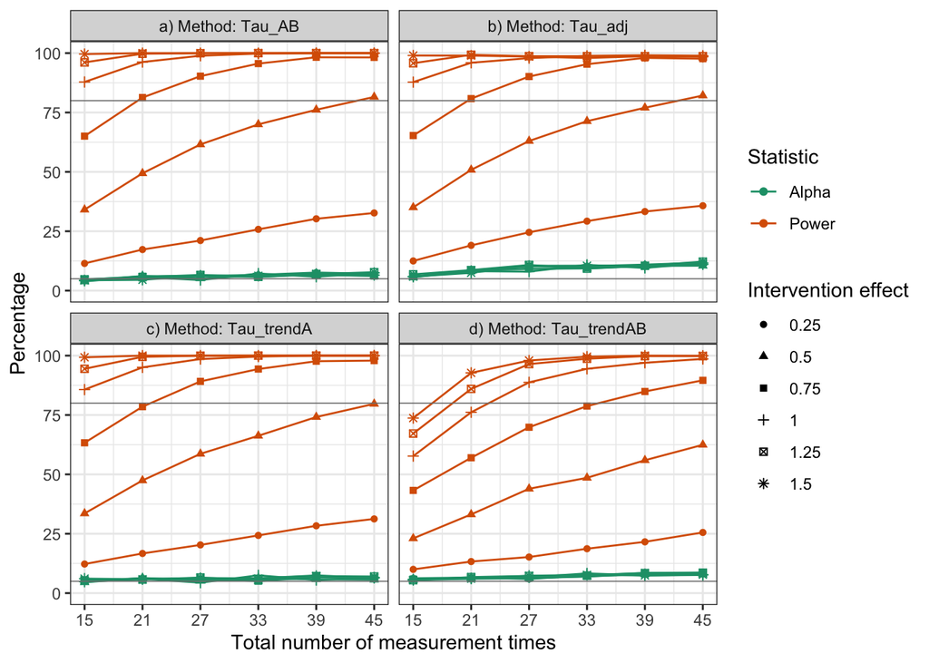

| Intervention effect | Measurement times | Power Tau<sub>AB</sub> | Power Tau<sub>trendA</sub> | Power Tau<sub>trendA+B</sub> | Power Tau<sub>adj</sub> | Alpha error Tau<sub>AB</sub> | Alpha error Tau<sub>trendA</sub> | Alpha error Tau<sub>trendA+B</sub> | Alpha error Tau<sub>adj</sub> | Correct Tau<sub>AB</sub> | Correct Tau<sub>trendA</sub> | Correct Tau<sub>trendA+B</sub> | Correct Tau<sub>adj</sub> |
| --- | --- | --- | --- | --- | --- | --- | --- | --- | --- | --- | --- | --- | --- |
| 0.25 | 15 | 11 | 12 | 10 | 12 | 4 | 5 | 6 | 6 | 54 | 53 | 52 | 53 |
| 0.25 | 21 | 17 | 17 | 13 | 19 | 5 | 6 | 7 | 8 | 56 | 55 | 53 | 55 |
| 0.25 | 27 | 21 | 20 | 15 | 25 | 6 | 6 | 6 | 10 | 58 | 57 | 55 | 57 |
| 0.25 | 33 | 26 | 24 | 19 | 29 | 7 | 6 | 8 | 10 | 60 | 59 | 56 | 59 |
| 0.25 | 39 | 30 | 28 | 22 | 33 | 8 | 7 | 8 | 11 | 61 | 60 | 57 | 61 |
| 0.25 | 45 | 33 | 31 | 26 | 36 | 7 | 6 | 9 | 12 | 63 | 62 | 58 | 62 |
| 0.50 | 15 | 34 | 34 | 23 | 35 | 4 | 5 | 6 | 6 | 65 | 64 | 59 | 65 |
| 0.50 | 21 | 49 | 47 | 33 | 51 | 6 | 6 | 6 | 8 | 72 | 71 | 63 | 71 |
| 0.50 | 27 | 62 | 59 | 44 | 63 | 5 | 5 | 6 | 9 | 78 | 77 | 69 | 77 |
| 0.50 | 33 | 70 | 66 | 49 | 71 | 6 | 6 | 7 | 9 | 82 | 80 | 71 | 81 |
| 0.50 | 39 | 76 | 74 | 56 | 77 | 6 | 6 | 8 | 10 | 85 | 84 | 74 | 83 |
| 0.50 | 45 | 82 | 80 | 62 | 82 | 6 | 6 | 8 | 10 | 88 | 87 | 77 | 86 |
| 0.75 | 15 | 65 | 63 | 43 | 65 | 5 | 5 | 6 | 6 | 80 | 79 | 69 | 80 |
| 0.75 | 21 | 81 | 78 | 57 | 81 | 6 | 6 | 6 | 8 | 88 | 86 | 75 | 86 |
| 0.75 | 27 | 90 | 89 | 70 | 90 | 6 | 6 | 6 | 10 | 92 | 92 | 82 | 90 |
| 0.75 | 33 | 96 | 94 | 79 | 95 | 6 | 5 | 7 | 10 | 95 | 95 | 86 | 93 |
| 0.75 | 39 | 98 | 98 | 85 | 98 | 7 | 7 | 8 | 11 | 96 | 95 | 88 | 94 |
| 0.75 | 45 | 98 | 98 | 90 | 98 | 6 | 6 | 8 | 11 | 96 | 96 | 91 | 93 |
| 1.00 | 15 | 88 | 86 | 58 | 88 | 4 | 5 | 6 | 6 | 92 | 90 | 76 | 91 |
| 1.00 | 21 | 96 | 95 | 76 | 96 | 6 | 6 | 6 | 8 | 95 | 94 | 85 | 94 |
| 1.00 | 27 | 99 | 99 | 89 | 98 | 4 | 4 | 7 | 8 | 97 | 97 | 91 | 95 |
| 1.00 | 33 | 100 | 100 | 94 | 99 | 7 | 8 | 8 | 11 | 96 | 96 | 93 | 94 |
| 1.00 | 39 | 100 | 100 | 97 | 99 | 6 | 6 | 7 | 10 | 97 | 97 | 95 | 95 |
| 1.00 | 45 | 100 | 100 | 99 | 99 | 8 | 7 | 8 | 12 | 96 | 97 | 95 | 94 |
| 1.25 | 15 | 96 | 94 | 67 | 96 | 5 | 5 | 5 | 7 | 96 | 95 | 81 | 94 |
| 1.25 | 21 | 100 | 100 | 86 | 99 | 6 | 6 | 7 | 9 | 97 | 97 | 90 | 95 |
| 1.25 | 27 | 100 | 100 | 96 | 99 | 7 | 7 | 7 | 11 | 97 | 97 | 95 | 94 |
| 1.25 | 33 | 100 | 100 | 99 | 99 | 6 | 5 | 7 | 9 | 97 | 97 | 96 | 95 |
| 1.25 | 39 | 100 | 100 | 100 | 99 | 7 | 7 | 8 | 10 | 97 | 96 | 96 | 94 |
| 1.25 | 45 | 100 | 100 | 100 | 99 | 8 | 7 | 9 | 12 | 96 | 96 | 96 | 93 |
| 1.50 | 15 | 100 | 99 | 74 | 99 | 4 | 6 | 6 | 6 | 98 | 97 | 84 | 97 |
| 1.50 | 21 | 100 | 100 | 93 | 99 | 5 | 6 | 6 | 8 | 98 | 97 | 93 | 96 |
| 1.50 | 27 | 100 | 100 | 98 | 99 | 6 | 6 | 7 | 10 | 97 | 97 | 95 | 94 |
| 1.50 | 33 | 100 | 100 | 100 | 98 | 6 | 6 | 8 | 10 | 97 | 97 | 96 | 94 |
| 1.50 | 39 | 100 | 100 | 100 | 99 | 7 | 7 | 7 | 10 | 96 | 96 | 96 | 94 |
| 1.50 | 45 | 100 | 100 | 100 | 98 | 7 | 6 | 8 | 11 | 97 | 97 | 96 | 94 |

| Intervention effect | Measurement times | Power Tau<sub>AB</sub> | Power Tau<sub>trendA</sub> | Power Tau<sub>trendA+B</sub> | Power Tau<sub>adj</sub> | Alpha error Tau<sub>AB</sub> | Alpha error Tau<sub>trendA</sub> | Alpha error Tau<sub>trendA+B</sub> | Alpha error Tau<sub>adj</sub> | Correct Tau<sub>AB</sub> | Correct Tau<sub>trendA</sub> | Correct Tau<sub>trendA+B</sub> | Correct Tau<sub>adj</sub> |
| --- | --- | --- | --- | --- | --- | --- | --- | --- | --- | --- | --- | --- | --- |
| 0.25 | 15 | 11.45 | 1 | -1 | 1 | 4.40 | 1 | 2 | 1 | 53.525 | 0 | -2 | 0 |
| 0.25 | 21 | 17.30 | -1 | -4 | 2 | 5.05 | 1 | 2 | 3 | 56.125 | -1 | -3 | -1 |
| 0.25 | 27 | 21.10 | -1 | -6 | 3 | 6.05 | 0 | 0 | 4 | 57.525 | 0 | -3 | 0 |
| 0.25 | 33 | 25.80 | -2 | -7 | 3 | 6.65 | 0 | 1 | 4 | 59.575 | -1 | -4 | 0 |
| 0.25 | 39 | 30.25 | -2 | -9 | 3 | 7.60 | 0 | 1 | 3 | 61.325 | -1 | -5 | 0 |
| 0.25 | 45 | 32.70 | -1 | -7 | 3 | 7.10 | -1 | 2 | 5 | 62.800 | 0 | -4 | -1 |
| 0.50 | 15 | 34.10 | -1 | -11 | 1 | 3.85 | 1 | 2 | 2 | 65.125 | -1 | -6 | 0 |
| 0.50 | 21 | 49.40 | -2 | -16 | 1 | 6.20 | 0 | 0 | 2 | 71.600 | -1 | -8 | 0 |
| 0.50 | 27 | 61.55 | -3 | -18 | 1 | 5.15 | 0 | 1 | 4 | 78.200 | -1 | -9 | -1 |
| 0.50 | 33 | 70.00 | -4 | -21 | 1 | 6.40 | 0 | 1 | 3 | 81.800 | -2 | -11 | -1 |
| 0.50 | 39 | 76.15 | -2 | -20 | 1 | 6.45 | -1 | 2 | 4 | 84.850 | -1 | -11 | -2 |
| 0.50 | 45 | 81.55 | -2 | -19 | 1 | 6.30 | -1 | 1 | 4 | 87.625 | -1 | -10 | -2 |
| 0.75 | 15 | 65.05 | -2 | -22 | 0 | 4.55 | 1 | 1 | 1 | 80.250 | -1 | -12 | -1 |
| 0.75 | 21 | 81.30 | -3 | -24 | 0 | 6.05 | 0 | 0 | 2 | 87.625 | -1 | -12 | -1 |
| 0.75 | 27 | 90.30 | -1 | -20 | 0 | 6.25 | 0 | 0 | 4 | 92.025 | 0 | -10 | -2 |
| 0.75 | 33 | 95.60 | -1 | -17 | 0 | 5.75 | -1 | 1 | 4 | 94.925 | 0 | -9 | -2 |
| 0.75 | 39 | 98.25 | -1 | -13 | 0 | 6.90 | 0 | 1 | 4 | 95.675 | 0 | -7 | -2 |
| 0.75 | 45 | 98.20 | 0 | -9 | -1 | 6.15 | 0 | 2 | 5 | 96.025 | 0 | -5 | -3 |
| 1.00 | 15 | 87.85 | -2 | -30 | 0 | 4.15 | 1 | 2 | 2 | 91.850 | -1 | -16 | -1 |
| 1.00 | 21 | 96.25 | -1 | -20 | 0 | 5.70 | 0 | 1 | 3 | 95.275 | -1 | -10 | -1 |
| 1.00 | 27 | 98.90 | 0 | -10 | -1 | 4.45 | 0 | 2 | 4 | 97.225 | 0 | -6 | -2 |
| 1.00 | 33 | 99.80 | 0 | -5 | -1 | 7.20 | 0 | 1 | 4 | 96.300 | 0 | -3 | -2 |
| 1.00 | 39 | 100.00 | 0 | -3 | -1 | 5.85 | 0 | 2 | 4 | 97.075 | 0 | -2 | -2 |
| 1.00 | 45 | 100.00 | 0 | -1 | -1 | 7.50 | -1 | 0 | 4 | 96.250 | 0 | -1 | -3 |
| 1.25 | 15 | 96.10 | -2 | -29 | 0 | 4.75 | 1 | 1 | 2 | 95.675 | -1 | -15 | -1 |
| 1.25 | 21 | 99.75 | 0 | -14 | 0 | 5.70 | 0 | 1 | 3 | 97.025 | 0 | -7 | -2 |
| 1.25 | 27 | 99.95 | 0 | -4 | -1 | 6.60 | 0 | 1 | 4 | 96.675 | 0 | -2 | -3 |
| 1.25 | 33 | 100.00 | 0 | -1 | -1 | 5.80 | 0 | 2 | 3 | 97.100 | 0 | -1 | -2 |
| 1.25 | 39 | 100.00 | 0 | 0 | -1 | 6.95 | 0 | 2 | 3 | 96.525 | 0 | -1 | -2 |
| 1.25 | 45 | 100.00 | 0 | 0 | -1 | 7.75 | -1 | 1 | 4 | 96.125 | 0 | -1 | -3 |
| 1.50 | 15 | 99.60 | 0 | -26 | -1 | 4.35 | 2 | 1 | 2 | 97.625 | -1 | -14 | -1 |
| 1.50 | 21 | 100.00 | 0 | -7 | -1 | 4.55 | 1 | 2 | 3 | 97.725 | -1 | -4 | -2 |
| 1.50 | 27 | 100.00 | 0 | -2 | -1 | 6.35 | 0 | 1 | 4 | 96.825 | 0 | -2 | -3 |
| 1.50 | 33 | 100.00 | 0 | 0 | -2 | 6.25 | 0 | 1 | 4 | 96.875 | 0 | -1 | -3 |
| 1.50 | 39 | 100.00 | 0 | 0 | -1 | 7.05 | 0 | 0 | 3 | 96.475 | 0 | 0 | -2 |
| 1.50 | 45 | 100.00 | 0 | 0 | -2 | 6.55 | 0 | 1 | 4 | 96.725 | 0 | -1 | -3 |

## Mean Tau-U

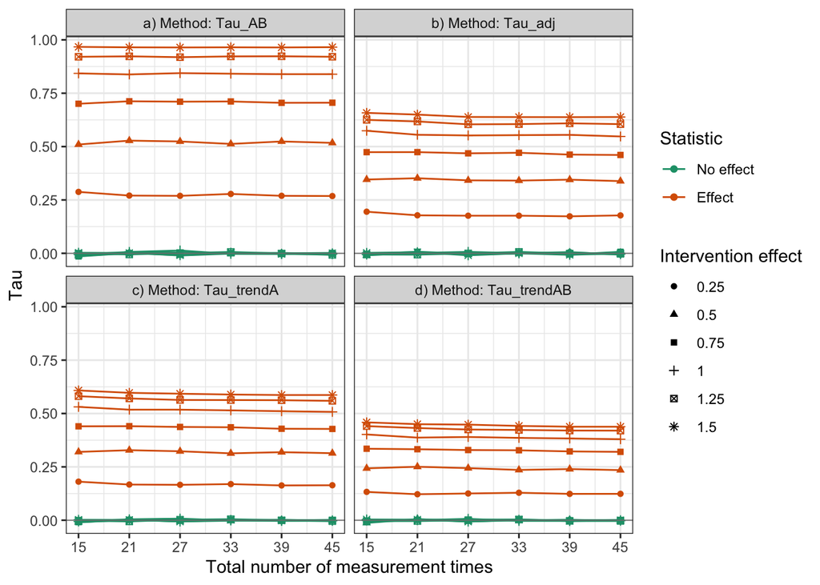

| Intervention effect | Measurement times | Effect Tau<sub>AB</sub> | Effect Tau<sub>trendA</sub> | Effect Tau<sub>trendA+B</sub> | Effect Tau<sub>adj</sub> | No effect Tau<sub>AB</sub> | No effect Tau<sub>trendA</sub> | No effect Tau<sub>trendA+B</sub> | No effect Tau<sub>adj</sub> |
| --- | --- | --- | --- | --- | --- | --- | --- | --- | --- |
| 0.25 | 15 | 0.29 | 0.18 | 0.13 | 0.19 | -0.01 | -0.01 | -0.01 | -0.01 |
| 0.25 | 21 | 0.27 | 0.17 | 0.12 | 0.18 | 0.00 | 0.00 | 0.00 | 0.00 |
| 0.25 | 27 | 0.27 | 0.17 | 0.13 | 0.18 | 0.00 | 0.00 | 0.00 | 0.00 |
| 0.25 | 33 | 0.28 | 0.17 | 0.13 | 0.18 | 0.00 | 0.00 | 0.00 | 0.00 |
| 0.25 | 39 | 0.27 | 0.16 | 0.12 | 0.17 | 0.00 | 0.00 | 0.00 | 0.01 |
| 0.25 | 45 | 0.27 | 0.16 | 0.12 | 0.18 | 0.00 | 0.00 | 0.00 | -0.01 |
| 0.50 | 15 | 0.51 | 0.32 | 0.24 | 0.35 | -0.01 | -0.01 | -0.01 | -0.01 |
| 0.50 | 21 | 0.53 | 0.33 | 0.25 | 0.35 | 0.00 | 0.00 | 0.01 | 0.00 |
| 0.50 | 27 | 0.52 | 0.32 | 0.24 | 0.34 | -0.01 | -0.01 | -0.01 | -0.01 |
| 0.50 | 33 | 0.51 | 0.31 | 0.24 | 0.34 | 0.00 | 0.00 | 0.00 | 0.00 |
| 0.50 | 39 | 0.52 | 0.32 | 0.24 | 0.35 | 0.00 | 0.00 | 0.00 | 0.00 |
| 0.50 | 45 | 0.52 | 0.31 | 0.23 | 0.34 | 0.00 | 0.00 | 0.00 | 0.00 |
| 0.75 | 15 | 0.70 | 0.44 | 0.33 | 0.47 | -0.01 | -0.01 | 0.00 | 0.00 |
| 0.75 | 21 | 0.71 | 0.44 | 0.33 | 0.47 | 0.00 | 0.00 | 0.00 | 0.01 |
| 0.75 | 27 | 0.71 | 0.44 | 0.33 | 0.47 | 0.00 | 0.00 | 0.00 | 0.00 |
| 0.75 | 33 | 0.71 | 0.44 | 0.33 | 0.47 | 0.00 | 0.00 | 0.00 | 0.00 |
| 0.75 | 39 | 0.71 | 0.43 | 0.32 | 0.46 | 0.00 | 0.00 | 0.00 | -0.01 |
| 0.75 | 45 | 0.71 | 0.43 | 0.32 | 0.46 | 0.00 | 0.00 | 0.00 | 0.01 |
| 1.00 | 15 | 0.84 | 0.53 | 0.40 | 0.57 | -0.01 | -0.01 | 0.00 | -0.01 |
| 1.00 | 21 | 0.84 | 0.52 | 0.39 | 0.56 | 0.01 | 0.00 | 0.00 | 0.00 |
| 1.00 | 27 | 0.84 | 0.52 | 0.39 | 0.55 | 0.01 | 0.01 | 0.01 | 0.01 |
| 1.00 | 33 | 0.84 | 0.51 | 0.39 | 0.55 | 0.00 | 0.00 | 0.00 | 0.00 |
| 1.00 | 39 | 0.84 | 0.51 | 0.38 | 0.55 | 0.00 | 0.00 | 0.00 | 0.00 |
| 1.00 | 45 | 0.84 | 0.51 | 0.38 | 0.55 | 0.00 | 0.00 | 0.00 | 0.00 |
| 1.25 | 15 | 0.92 | 0.58 | 0.44 | 0.63 | 0.00 | 0.00 | 0.00 | -0.01 |
| 1.25 | 21 | 0.92 | 0.57 | 0.43 | 0.62 | -0.01 | -0.01 | 0.00 | -0.01 |
| 1.25 | 27 | 0.92 | 0.56 | 0.42 | 0.60 | 0.00 | 0.00 | 0.00 | 0.00 |
| 1.25 | 33 | 0.92 | 0.56 | 0.42 | 0.61 | 0.01 | 0.00 | 0.00 | 0.01 |
| 1.25 | 39 | 0.92 | 0.56 | 0.42 | 0.61 | 0.00 | 0.00 | 0.00 | 0.00 |
| 1.25 | 45 | 0.92 | 0.56 | 0.42 | 0.61 | -0.01 | 0.00 | 0.00 | 0.00 |
| 1.50 | 15 | 0.97 | 0.61 | 0.46 | 0.66 | 0.00 | 0.00 | 0.00 | 0.00 |
| 1.50 | 21 | 0.97 | 0.60 | 0.45 | 0.65 | 0.00 | 0.00 | 0.00 | 0.01 |
| 1.50 | 27 | 0.96 | 0.59 | 0.45 | 0.64 | -0.01 | -0.01 | -0.01 | -0.01 |
| 1.50 | 33 | 0.97 | 0.59 | 0.44 | 0.64 | 0.00 | 0.00 | 0.00 | 0.00 |
| 1.50 | 39 | 0.96 | 0.59 | 0.44 | 0.64 | 0.00 | 0.00 | 0.00 | -0.01 |
| 1.50 | 45 | 0.97 | 0.59 | 0.44 | 0.64 | 0.00 | 0.00 | 0.00 | 0.00 |

| Intervention effect | Measurement times | Effect Tau<sub>AB</sub> | Effect Tau<sub>trendA</sub> | Effect Tau<sub>trendA+B</sub> | Effect Tau<sub>adj</sub> | No effect Tau<sub>AB</sub> | No effect Tau<sub>trendA</sub> | No effect Tau<sub>trendA+B</sub> | No effect Tau<sub>adj</sub> |
| --- | --- | --- | --- | --- | --- | --- | --- | --- | --- |
| 0.25 | 15 | 0.29 | -0.11 | -0.16 | -0.10 | -0.01 | 0.00 | 0.00 | 0.00 |
| 0.25 | 21 | 0.27 | -0.10 | -0.15 | -0.09 | 0.00 | 0.00 | 0.00 | 0.00 |
| 0.25 | 27 | 0.27 | -0.10 | -0.14 | -0.09 | 0.00 | 0.00 | 0.00 | 0.00 |
| 0.25 | 33 | 0.28 | -0.11 | -0.15 | -0.10 | 0.00 | 0.00 | 0.00 | 0.00 |
| 0.25 | 39 | 0.27 | -0.11 | -0.15 | -0.10 | 0.00 | 0.00 | 0.00 | 0.01 |
| 0.25 | 45 | 0.27 | -0.11 | -0.15 | -0.09 | 0.00 | 0.00 | 0.00 | -0.01 |
| 0.50 | 15 | 0.51 | -0.19 | -0.27 | -0.16 | -0.01 | 0.00 | 0.00 | 0.00 |
| 0.50 | 21 | 0.53 | -0.20 | -0.28 | -0.18 | 0.00 | 0.00 | 0.01 | 0.00 |
| 0.50 | 27 | 0.52 | -0.20 | -0.28 | -0.18 | -0.01 | 0.00 | 0.00 | 0.00 |
| 0.50 | 33 | 0.51 | -0.20 | -0.27 | -0.17 | 0.00 | 0.00 | 0.00 | 0.00 |
| 0.50 | 39 | 0.52 | -0.20 | -0.28 | -0.17 | 0.00 | 0.00 | 0.00 | 0.00 |
| 0.50 | 45 | 0.52 | -0.21 | -0.29 | -0.18 | 0.00 | 0.00 | 0.00 | 0.00 |
| 0.75 | 15 | 0.70 | -0.26 | -0.37 | -0.23 | -0.01 | 0.00 | 0.01 | 0.01 |
| 0.75 | 21 | 0.71 | -0.27 | -0.38 | -0.24 | 0.00 | 0.00 | 0.00 | 0.01 |
| 0.75 | 27 | 0.71 | -0.27 | -0.38 | -0.24 | 0.00 | 0.00 | 0.00 | 0.00 |
| 0.75 | 33 | 0.71 | -0.27 | -0.38 | -0.24 | 0.00 | 0.00 | 0.00 | 0.00 |
| 0.75 | 39 | 0.71 | -0.28 | -0.39 | -0.25 | 0.00 | 0.00 | 0.00 | -0.01 |
| 0.75 | 45 | 0.71 | -0.28 | -0.39 | -0.25 | 0.00 | 0.00 | 0.00 | 0.01 |
| 1.00 | 15 | 0.84 | -0.31 | -0.44 | -0.27 | -0.01 | 0.00 | 0.01 | 0.00 |
| 1.00 | 21 | 0.84 | -0.32 | -0.45 | -0.28 | 0.01 | -0.01 | -0.01 | -0.01 |
| 1.00 | 27 | 0.84 | -0.32 | -0.45 | -0.29 | 0.01 | 0.00 | 0.00 | 0.00 |
| 1.00 | 33 | 0.84 | -0.33 | -0.45 | -0.29 | 0.00 | 0.00 | 0.00 | 0.00 |
| 1.00 | 39 | 0.84 | -0.33 | -0.46 | -0.29 | 0.00 | 0.00 | 0.00 | 0.00 |
| 1.00 | 45 | 0.84 | -0.33 | -0.46 | -0.29 | 0.00 | 0.00 | 0.00 | 0.00 |
| 1.25 | 15 | 0.92 | -0.34 | -0.48 | -0.29 | 0.00 | 0.00 | 0.00 | -0.01 |
| 1.25 | 21 | 0.92 | -0.35 | -0.49 | -0.30 | -0.01 | 0.00 | 0.01 | 0.00 |
| 1.25 | 27 | 0.92 | -0.36 | -0.50 | -0.32 | 0.00 | 0.00 | 0.00 | 0.00 |
| 1.25 | 33 | 0.92 | -0.36 | -0.50 | -0.31 | 0.01 | -0.01 | -0.01 | 0.00 |
| 1.25 | 39 | 0.92 | -0.36 | -0.50 | -0.31 | 0.00 | 0.00 | 0.00 | 0.00 |
| 1.25 | 45 | 0.92 | -0.36 | -0.50 | -0.31 | -0.01 | 0.01 | 0.01 | 0.01 |
| 1.50 | 15 | 0.97 | -0.36 | -0.51 | -0.31 | 0.00 | 0.00 | 0.00 | 0.00 |
| 1.50 | 21 | 0.97 | -0.37 | -0.52 | -0.32 | 0.00 | 0.00 | 0.00 | 0.01 |
| 1.50 | 27 | 0.96 | -0.37 | -0.51 | -0.32 | -0.01 | 0.00 | 0.00 | 0.00 |
| 1.50 | 33 | 0.97 | -0.38 | -0.53 | -0.33 | 0.00 | 0.00 | 0.00 | 0.00 |
| 1.50 | 39 | 0.96 | -0.37 | -0.52 | -0.32 | 0.00 | 0.00 | 0.00 | -0.01 |
| 1.50 | 45 | 0.97 | -0.38 | -0.53 | -0.33 | 0.00 | 0.00 | 0.00 | 0.00 |

## Parameters

**Iterations:**  
level_effect = c(0.25, 0.5, 0.75, 1, 1.25, 1.5)  
length = c(15, 21, 27, 33, 39, 45)  
n_sims = 2000  
**Design:**  
n = n_sims  
start_value = 50  
s = 10  
level = level_effect  
trend = rnorm(n_sims, 0, 0.1/length)  
slope = rnorm(n_sims, 0, 0.1/(length * 2/3))  
phase_design = list(A = length * 1/3, B = length * 2/3)  
distribution = gaussian

# Strength of trend effect and measurement-times

## Percentage significant

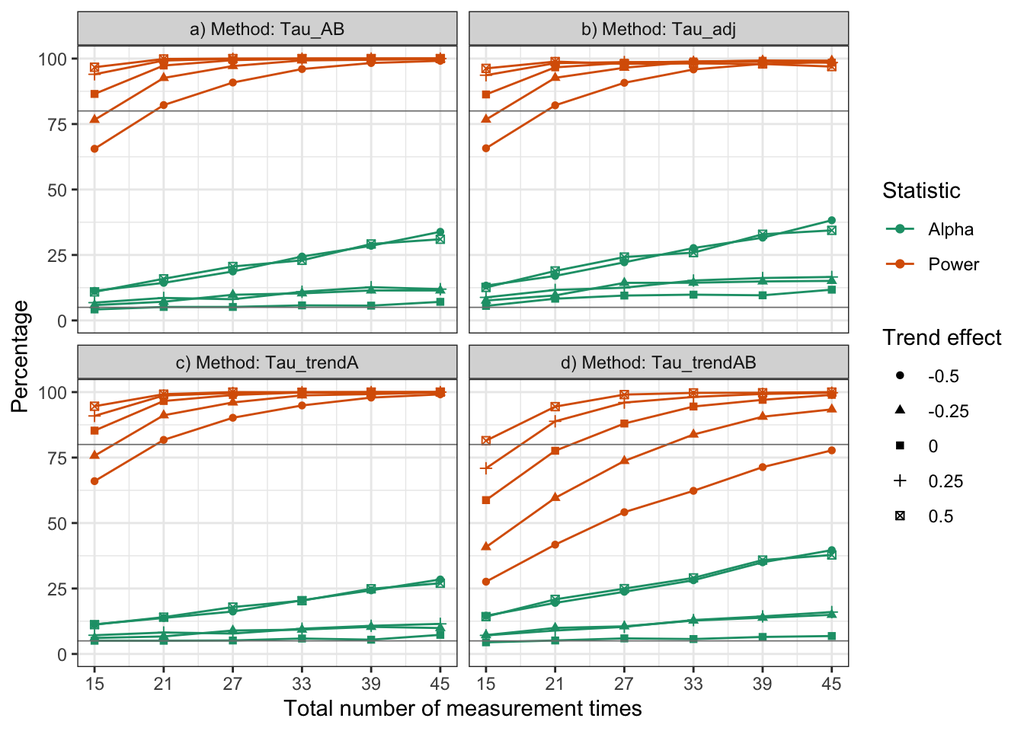

| Trend effect | Measurement times | Power Tau<sub>AB</sub> | Power Tau<sub>trendA</sub> | Power Tau<sub>trendA+B</sub> | Power Tau<sub>adj</sub> | Alpha error Tau<sub>AB</sub> | Alpha error Tau<sub>trendA</sub> | Alpha error Tau<sub>trendA+B</sub> | Alpha error Tau<sub>adj</sub> | Correct Tau<sub>AB</sub> | Correct Tau<sub>trendA</sub> | Correct Tau<sub>trendA+B</sub> | Correct Tau<sub>adj</sub> |
| --- | --- | --- | --- | --- | --- | --- | --- | --- | --- | --- | --- | --- | --- |
| -0.50 | 15 | 66 | 66 | 28 | 66 | 11 | 11 | 15 | 13 | 77 | 77 | 56 | 76 |
| -0.50 | 21 | 82 | 82 | 42 | 82 | 14 | 14 | 20 | 17 | 84 | 84 | 61 | 83 |
| -0.50 | 27 | 91 | 90 | 54 | 91 | 19 | 16 | 24 | 22 | 86 | 87 | 65 | 84 |
| -0.50 | 33 | 96 | 95 | 62 | 96 | 24 | 20 | 28 | 28 | 86 | 87 | 67 | 84 |
| -0.50 | 39 | 98 | 98 | 71 | 98 | 28 | 24 | 35 | 32 | 85 | 87 | 68 | 83 |
| -0.50 | 45 | 99 | 99 | 78 | 99 | 34 | 28 | 40 | 38 | 83 | 85 | 69 | 80 |
| -0.25 | 15 | 77 | 76 | 41 | 77 | 6 | 6 | 7 | 8 | 85 | 85 | 67 | 85 |
| -0.25 | 21 | 93 | 91 | 60 | 93 | 7 | 7 | 10 | 10 | 93 | 92 | 75 | 92 |
| -0.25 | 27 | 97 | 96 | 74 | 96 | 10 | 9 | 11 | 14 | 94 | 94 | 82 | 91 |
| -0.25 | 33 | 99 | 99 | 84 | 99 | 10 | 9 | 13 | 14 | 94 | 95 | 86 | 92 |
| -0.25 | 39 | 100 | 99 | 91 | 99 | 11 | 10 | 14 | 15 | 94 | 94 | 88 | 92 |
| -0.25 | 45 | 100 | 100 | 93 | 99 | 11 | 10 | 15 | 15 | 94 | 95 | 89 | 92 |
| 0.00 | 15 | 86 | 85 | 59 | 86 | 4 | 5 | 4 | 6 | 91 | 90 | 77 | 90 |
| 0.00 | 21 | 97 | 97 | 78 | 97 | 5 | 5 | 5 | 8 | 96 | 96 | 86 | 94 |
| 0.00 | 27 | 99 | 99 | 88 | 98 | 5 | 5 | 6 | 10 | 97 | 97 | 91 | 94 |
| 0.00 | 33 | 100 | 100 | 94 | 99 | 6 | 6 | 6 | 10 | 97 | 97 | 94 | 95 |
| 0.00 | 39 | 100 | 100 | 97 | 99 | 6 | 5 | 6 | 10 | 97 | 97 | 95 | 95 |
| 0.00 | 45 | 100 | 100 | 99 | 98 | 7 | 7 | 7 | 12 | 96 | 96 | 96 | 93 |
| 0.25 | 15 | 94 | 91 | 71 | 94 | 7 | 7 | 7 | 9 | 94 | 92 | 82 | 92 |
| 0.25 | 21 | 99 | 99 | 89 | 98 | 9 | 8 | 9 | 12 | 95 | 95 | 90 | 93 |
| 0.25 | 27 | 100 | 100 | 96 | 99 | 8 | 8 | 10 | 12 | 96 | 96 | 93 | 93 |
| 0.25 | 33 | 100 | 100 | 98 | 99 | 11 | 10 | 13 | 15 | 94 | 95 | 93 | 92 |
| 0.25 | 39 | 100 | 100 | 99 | 99 | 13 | 11 | 14 | 16 | 94 | 95 | 92 | 91 |
| 0.25 | 45 | 100 | 100 | 100 | 98 | 12 | 12 | 16 | 17 | 94 | 94 | 92 | 91 |
| 0.50 | 15 | 97 | 95 | 81 | 96 | 11 | 11 | 14 | 13 | 93 | 92 | 84 | 92 |
| 0.50 | 21 | 100 | 99 | 94 | 99 | 16 | 14 | 21 | 19 | 92 | 93 | 87 | 90 |
| 0.50 | 27 | 100 | 100 | 99 | 98 | 21 | 18 | 25 | 24 | 90 | 91 | 87 | 87 |
| 0.50 | 33 | 100 | 100 | 100 | 98 | 23 | 20 | 29 | 26 | 89 | 90 | 85 | 86 |
| 0.50 | 39 | 100 | 100 | 100 | 98 | 29 | 25 | 36 | 33 | 85 | 88 | 82 | 83 |
| 0.50 | 45 | 100 | 100 | 100 | 97 | 31 | 27 | 38 | 34 | 84 | 86 | 81 | 81 |

| Trend effect | Measurement times | Power Tau<sub>AB</sub> | Power Tau<sub>trendA</sub> | Power Tau<sub>trendA+B</sub> | Power Tau<sub>adj</sub> | Alpha error Tau<sub>AB</sub> | Alpha error Tau<sub>trendA</sub> | Alpha error Tau<sub>trendA+B</sub> | Alpha error Tau<sub>adj</sub> | Correct Tau<sub>AB</sub> | Correct Tau<sub>trendA</sub> | Correct Tau<sub>trendA+B</sub> | Correct Tau<sub>adj</sub> |
| --- | --- | --- | --- | --- | --- | --- | --- | --- | --- | --- | --- | --- | --- |
| -0.50 | 15 | 65.55 | 0 | -38 | 0 | 11.30 | 0 | 3 | 2 | 77.125 | 0 | -21 | -1 |
| -0.50 | 21 | 82.25 | 0 | -40 | 0 | 14.35 | -1 | 5 | 3 | 83.950 | 0 | -23 | -1 |
| -0.50 | 27 | 90.85 | -1 | -37 | 0 | 18.70 | -2 | 5 | 4 | 86.075 | 1 | -21 | -2 |
| -0.50 | 33 | 96.00 | -1 | -34 | 0 | 24.40 | -4 | 4 | 3 | 85.800 | 1 | -19 | -2 |
| -0.50 | 39 | 98.30 | 0 | -27 | 0 | 28.50 | -4 | 7 | 3 | 84.900 | 2 | -17 | -2 |
| -0.50 | 45 | 99.15 | 0 | -21 | 0 | 33.85 | -5 | 6 | 4 | 82.650 | 3 | -14 | -2 |
| -0.25 | 15 | 76.60 | -1 | -36 | 0 | 5.85 | 0 | 1 | 2 | 85.375 | -1 | -19 | -1 |
| -0.25 | 21 | 92.60 | -1 | -33 | 0 | 7.15 | 0 | 3 | 2 | 92.725 | 0 | -18 | -1 |
| -0.25 | 27 | 97.15 | -1 | -23 | -1 | 9.80 | -1 | 1 | 5 | 93.675 | 0 | -12 | -3 |
| -0.25 | 33 | 99.30 | -1 | -16 | 0 | 10.35 | -1 | 2 | 4 | 94.475 | 0 | -9 | -2 |
| -0.25 | 39 | 99.55 | 0 | -9 | 0 | 11.45 | -1 | 2 | 3 | 94.050 | 0 | -6 | -2 |
| -0.25 | 45 | 99.80 | 0 | -6 | -1 | 11.45 | -2 | 3 | 4 | 94.175 | 1 | -5 | -2 |
| 0.00 | 15 | 86.50 | -1 | -28 | 0 | 4.20 | 1 | 0 | 1 | 91.150 | -1 | -14 | -1 |
| 0.00 | 21 | 97.35 | -1 | -20 | -1 | 5.15 | 0 | 0 | 3 | 96.100 | 0 | -10 | -2 |
| 0.00 | 27 | 99.40 | 0 | -11 | -1 | 5.15 | 0 | 1 | 4 | 97.125 | 0 | -6 | -3 |
| 0.00 | 33 | 99.95 | 0 | -5 | -1 | 5.75 | 0 | 0 | 4 | 97.100 | 0 | -3 | -3 |
| 0.00 | 39 | 99.90 | 0 | -3 | -1 | 5.65 | 0 | 1 | 4 | 97.125 | 0 | -2 | -2 |
| 0.00 | 45 | 100.00 | 0 | -1 | -2 | 7.10 | 0 | 0 | 5 | 96.450 | 0 | 0 | -3 |
| 0.25 | 15 | 94.00 | -3 | -23 | 0 | 6.80 | 0 | 0 | 2 | 93.600 | -2 | -12 | -1 |
| 0.25 | 21 | 99.25 | -1 | -10 | -1 | 8.60 | 0 | 0 | 3 | 95.325 | 0 | -5 | -2 |
| 0.25 | 27 | 99.90 | 0 | -4 | -1 | 8.10 | 0 | 2 | 4 | 95.900 | 0 | -3 | -3 |
| 0.25 | 33 | 99.95 | 0 | -2 | -1 | 10.95 | -1 | 2 | 4 | 94.500 | 1 | -2 | -3 |
| 0.25 | 39 | 100.00 | 0 | -1 | -1 | 12.70 | -2 | 2 | 4 | 93.650 | 1 | -1 | -2 |
| 0.25 | 45 | 100.00 | 0 | 0 | -2 | 11.95 | 0 | 4 | 5 | 94.025 | 0 | -2 | -3 |
| 0.50 | 15 | 96.70 | -2 | -15 | 0 | 10.90 | 0 | 3 | 2 | 92.900 | -1 | -9 | -1 |
| 0.50 | 21 | 99.85 | -1 | -5 | -1 | 15.90 | -2 | 5 | 3 | 91.975 | 1 | -5 | -2 |
| 0.50 | 27 | 100.00 | 0 | -1 | -2 | 20.60 | -3 | 4 | 4 | 89.700 | 1 | -3 | -3 |
| 0.50 | 33 | 100.00 | 0 | 0 | -2 | 22.95 | -3 | 6 | 3 | 88.525 | 1 | -3 | -2 |
| 0.50 | 39 | 100.00 | 0 | 0 | -2 | 29.20 | -4 | 7 | 4 | 85.400 | 2 | -3 | -3 |
| 0.50 | 45 | 100.00 | 0 | 0 | -3 | 31.00 | -4 | 7 | 3 | 84.500 | 2 | -3 | -3 |

## Mean Tau-U

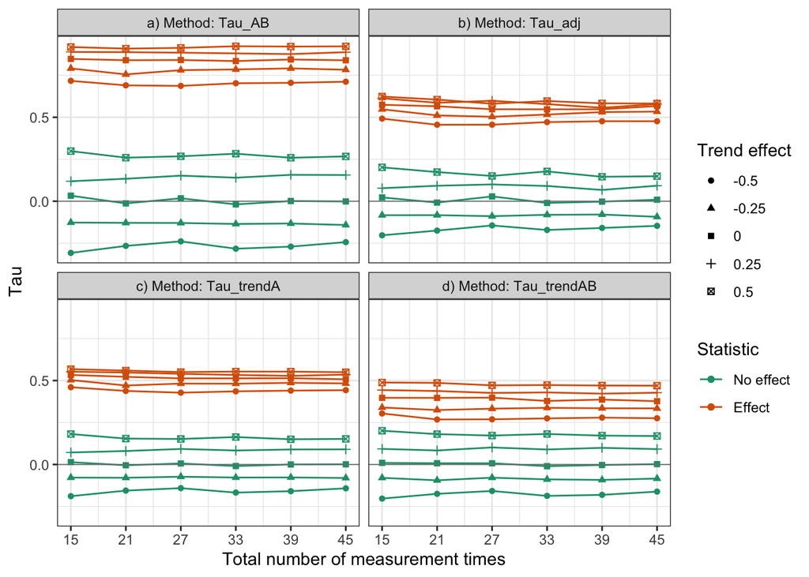

| Trend effect | Measurement times | Effect Tau<sub>AB</sub> | Effect Tau<sub>trendA</sub> | Effect Tau<sub>trendA+B</sub> | Effect Tau<sub>adj</sub> | No effect Tau<sub>AB</sub> | No effect Tau<sub>trendA</sub> | No effect Tau<sub>trendA+B</sub> | No effect Tau<sub>adj</sub> |
| --- | --- | --- | --- | --- | --- | --- | --- | --- | --- |
| -0.50 | 15 | 0.72 | 0.46 | 0.30 | 0.49 | -0.31 | -0.19 | -0.20 | -0.20 |
| -0.50 | 21 | 0.69 | 0.44 | 0.27 | 0.46 | -0.27 | -0.16 | -0.17 | -0.17 |
| -0.50 | 27 | 0.69 | 0.43 | 0.27 | 0.46 | -0.24 | -0.14 | -0.16 | -0.14 |
| -0.50 | 33 | 0.70 | 0.44 | 0.27 | 0.47 | -0.28 | -0.17 | -0.19 | -0.17 |
| -0.50 | 39 | 0.71 | 0.44 | 0.28 | 0.48 | -0.27 | -0.16 | -0.18 | -0.16 |
| -0.50 | 45 | 0.71 | 0.44 | 0.28 | 0.48 | -0.24 | -0.14 | -0.16 | -0.15 |
| -0.25 | 15 | 0.79 | 0.50 | 0.34 | 0.55 | -0.13 | -0.08 | -0.08 | -0.08 |
| -0.25 | 21 | 0.76 | 0.47 | 0.32 | 0.51 | -0.13 | -0.08 | -0.09 | -0.08 |
| -0.25 | 27 | 0.78 | 0.48 | 0.33 | 0.50 | -0.13 | -0.07 | -0.08 | -0.09 |
| -0.25 | 33 | 0.78 | 0.48 | 0.34 | 0.52 | -0.14 | -0.08 | -0.09 | -0.08 |
| -0.25 | 39 | 0.79 | 0.49 | 0.34 | 0.53 | -0.13 | -0.08 | -0.09 | -0.08 |
| -0.25 | 45 | 0.78 | 0.48 | 0.33 | 0.53 | -0.14 | -0.08 | -0.08 | -0.09 |
| 0.00 | 15 | 0.85 | 0.53 | 0.40 | 0.57 | 0.03 | 0.01 | 0.01 | 0.02 |
| 0.00 | 21 | 0.84 | 0.52 | 0.40 | 0.57 | -0.01 | 0.00 | 0.01 | -0.01 |
| 0.00 | 27 | 0.84 | 0.51 | 0.40 | 0.55 | 0.02 | 0.01 | 0.01 | 0.03 |
| 0.00 | 33 | 0.83 | 0.51 | 0.38 | 0.55 | -0.02 | -0.01 | -0.01 | -0.01 |
| 0.00 | 39 | 0.84 | 0.51 | 0.39 | 0.55 | 0.00 | 0.00 | 0.00 | 0.00 |
| 0.00 | 45 | 0.84 | 0.51 | 0.38 | 0.57 | 0.00 | 0.00 | 0.00 | 0.01 |
| 0.25 | 15 | 0.89 | 0.55 | 0.44 | 0.61 | 0.12 | 0.07 | 0.09 | 0.08 |
| 0.25 | 21 | 0.89 | 0.55 | 0.44 | 0.59 | 0.13 | 0.08 | 0.08 | 0.09 |
| 0.25 | 27 | 0.88 | 0.54 | 0.43 | 0.60 | 0.15 | 0.09 | 0.10 | 0.10 |
| 0.25 | 33 | 0.88 | 0.53 | 0.43 | 0.58 | 0.14 | 0.08 | 0.09 | 0.09 |
| 0.25 | 39 | 0.88 | 0.53 | 0.42 | 0.56 | 0.16 | 0.09 | 0.10 | 0.07 |
| 0.25 | 45 | 0.89 | 0.54 | 0.43 | 0.58 | 0.16 | 0.09 | 0.09 | 0.09 |
| 0.50 | 15 | 0.92 | 0.57 | 0.49 | 0.62 | 0.30 | 0.18 | 0.20 | 0.20 |
| 0.50 | 21 | 0.91 | 0.56 | 0.49 | 0.61 | 0.26 | 0.15 | 0.18 | 0.17 |
| 0.50 | 27 | 0.91 | 0.55 | 0.47 | 0.58 | 0.27 | 0.15 | 0.17 | 0.15 |
| 0.50 | 33 | 0.92 | 0.55 | 0.47 | 0.60 | 0.28 | 0.16 | 0.18 | 0.18 |
| 0.50 | 39 | 0.92 | 0.55 | 0.47 | 0.58 | 0.26 | 0.15 | 0.17 | 0.15 |
| 0.50 | 45 | 0.92 | 0.55 | 0.47 | 0.58 | 0.27 | 0.15 | 0.17 | 0.15 |

| Trend effect | Measurement times | Effect Tau<sub>AB</sub> | Effect Tau<sub>trendA</sub> | Effect Tau<sub>trendA+B</sub> | Effect Tau<sub>adj</sub> | No effect Tau<sub>AB</sub> | No effect Tau<sub>trendA</sub> | No effect Tau<sub>trendA+B</sub> | No effect Tau<sub>adj</sub> |
| --- | --- | --- | --- | --- | --- | --- | --- | --- | --- |
| -0.50 | 15 | 0.72 | -0.26 | -0.42 | -0.23 | -0.31 | 0.12 | 0.11 | 0.11 |
| -0.50 | 21 | 0.69 | -0.25 | -0.42 | -0.23 | -0.27 | 0.11 | 0.10 | 0.10 |
| -0.50 | 27 | 0.69 | -0.26 | -0.42 | -0.23 | -0.24 | 0.10 | 0.08 | 0.10 |
| -0.50 | 33 | 0.70 | -0.26 | -0.43 | -0.23 | -0.28 | 0.11 | 0.09 | 0.11 |
| -0.50 | 39 | 0.71 | -0.27 | -0.43 | -0.23 | -0.27 | 0.11 | 0.09 | 0.11 |
| -0.50 | 45 | 0.71 | -0.27 | -0.43 | -0.23 | -0.24 | 0.10 | 0.08 | 0.09 |
| -0.25 | 15 | 0.79 | -0.29 | -0.45 | -0.24 | -0.13 | 0.05 | 0.05 | 0.05 |
| -0.25 | 21 | 0.76 | -0.29 | -0.44 | -0.25 | -0.13 | 0.05 | 0.04 | 0.05 |
| -0.25 | 27 | 0.78 | -0.30 | -0.45 | -0.28 | -0.13 | 0.06 | 0.05 | 0.04 |
| -0.25 | 33 | 0.78 | -0.30 | -0.44 | -0.26 | -0.14 | 0.06 | 0.05 | 0.06 |
| -0.25 | 39 | 0.79 | -0.30 | -0.45 | -0.26 | -0.13 | 0.05 | 0.04 | 0.05 |
| -0.25 | 45 | 0.78 | -0.30 | -0.45 | -0.25 | -0.14 | 0.06 | 0.06 | 0.05 |
| 0.00 | 15 | 0.85 | -0.32 | -0.45 | -0.28 | 0.03 | -0.02 | -0.02 | -0.01 |
| 0.00 | 21 | 0.84 | -0.32 | -0.44 | -0.27 | -0.01 | 0.01 | 0.02 | 0.00 |
| 0.00 | 27 | 0.84 | -0.33 | -0.44 | -0.29 | 0.02 | -0.01 | -0.01 | 0.01 |
| 0.00 | 33 | 0.83 | -0.32 | -0.45 | -0.28 | -0.02 | 0.01 | 0.01 | 0.01 |
| 0.00 | 39 | 0.84 | -0.33 | -0.45 | -0.29 | 0.00 | 0.00 | 0.00 | 0.00 |
| 0.00 | 45 | 0.84 | -0.33 | -0.46 | -0.27 | 0.00 | 0.00 | 0.00 | 0.01 |
| 0.25 | 15 | 0.89 | -0.34 | -0.45 | -0.28 | 0.12 | -0.05 | -0.03 | -0.04 |
| 0.25 | 21 | 0.89 | -0.34 | -0.45 | -0.30 | 0.13 | -0.05 | -0.05 | -0.04 |
| 0.25 | 27 | 0.88 | -0.34 | -0.45 | -0.28 | 0.15 | -0.06 | -0.05 | -0.05 |
| 0.25 | 33 | 0.88 | -0.35 | -0.45 | -0.30 | 0.14 | -0.06 | -0.05 | -0.05 |
| 0.25 | 39 | 0.88 | -0.35 | -0.46 | -0.32 | 0.16 | -0.07 | -0.06 | -0.09 |
| 0.25 | 45 | 0.89 | -0.35 | -0.46 | -0.31 | 0.16 | -0.07 | -0.07 | -0.07 |
| 0.50 | 15 | 0.92 | -0.35 | -0.43 | -0.30 | 0.30 | -0.12 | -0.10 | -0.10 |
| 0.50 | 21 | 0.91 | -0.35 | -0.42 | -0.30 | 0.26 | -0.11 | -0.08 | -0.09 |
| 0.50 | 27 | 0.91 | -0.36 | -0.44 | -0.33 | 0.27 | -0.12 | -0.10 | -0.12 |
| 0.50 | 33 | 0.92 | -0.37 | -0.45 | -0.32 | 0.28 | -0.12 | -0.10 | -0.10 |
| 0.50 | 39 | 0.92 | -0.37 | -0.45 | -0.34 | 0.26 | -0.11 | -0.09 | -0.11 |
| 0.50 | 45 | 0.92 | -0.37 | -0.45 | -0.34 | 0.27 | -0.12 | -0.10 | -0.12 |